# Findings of 2012

The following variables are selected to see if the difference in income between men and women in 2012 vary depending on them:

1. race
2. number.drink.per.day.2012
3. residence.region.2012
4. highest.education.2012
5. family.size.2012
6. industry.2012

# T-Test

Use t.test to test if there is significant difference in income between male and female in 2012.

```
##
##  Welch Two Sample t-test
##
## data:  income.2012 by gender
## t = -17.789, df = 4166.1, p-value < 2.2e-16
## alternative hypothesis: true difference in means is not equal to 0
## 95 percent confidence interval:
##  -28793.89 -23077.06
## sample estimates:
## mean in group Female   mean in group Male
##             30657.24             56592.72
```

**The outcome shows that the average different in income between male and female in 2012 is 2.5935510^{4} dollar, with the p value 0**

# Model 1

In the first model, data of those whose income is more than 0 but not top coded is used to do linear regression. We divide the whole cleaned data frame into two parts, one male and one female, and do regression seperately.

First test if income is normally distributed using qqplot.

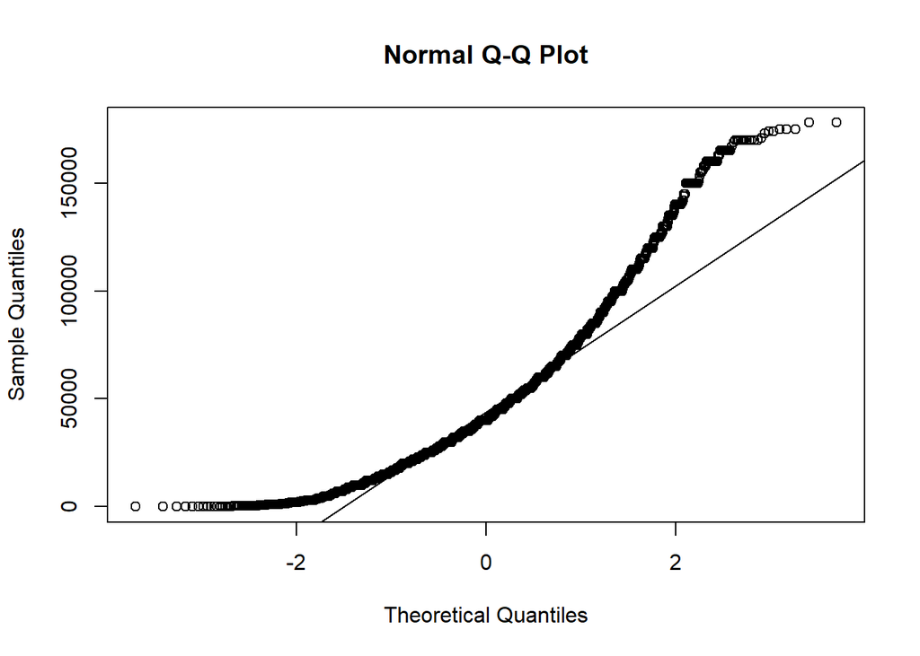

**The income is not normally distributed. So should be dealt with. Doing square root is a good way.**

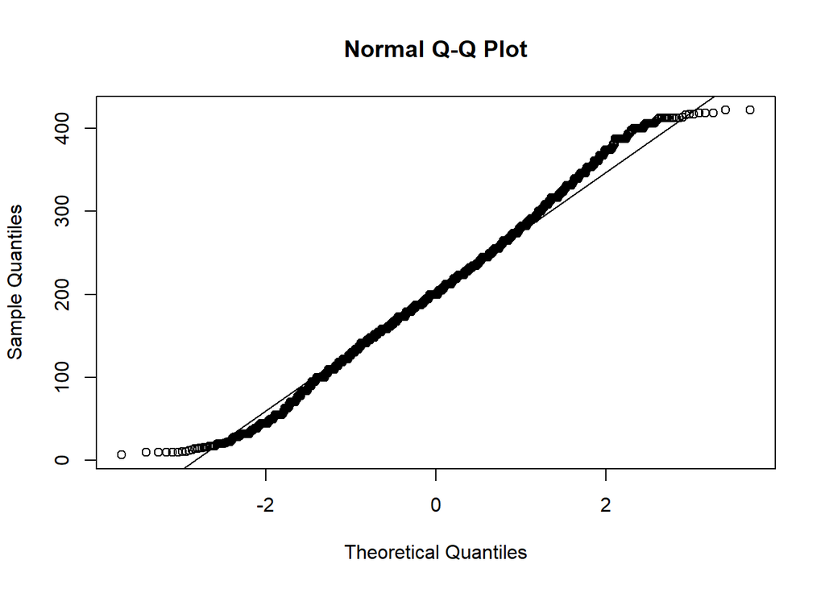

**Much better now.**

Divide the data frame into 2 by gender.

Then test if there are collinear variables. First male.

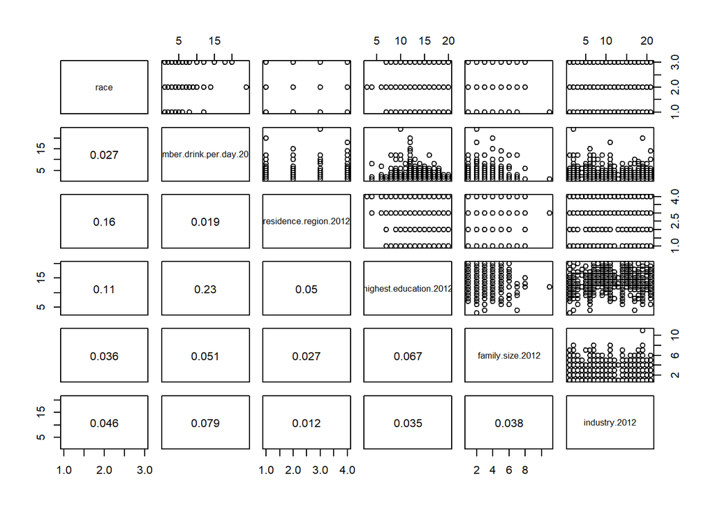

**There is no collinear**

Then female.

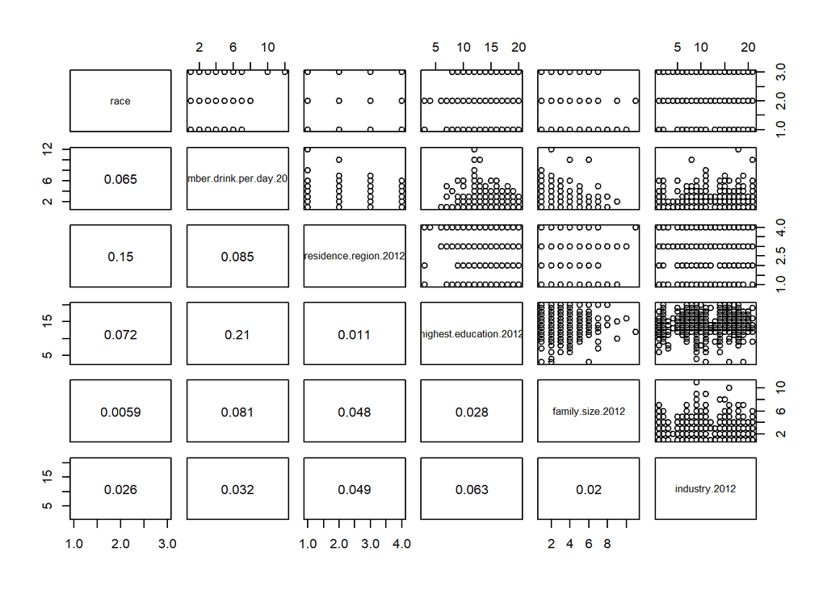

**There is no collinear**

Now can do linear regression.  
Regression summary of male:

|  | Estimate | Std. Error | t value | Pr(>\|t\|) |
| --- | --- | --- | --- | --- |
| (Intercept) | 28.9714098 | 15.1320810 | 1.9145688 | 0.0557575 |
| raceHispanic | 16.1276755 | 5.9114190 | 2.7282241 | 0.0064497 |
| raceOther | 26.4059212 | 4.5822518 | 5.7626517 | 0.0000000 |
| number.drink.per.day.2012 | -2.0440732 | 0.8384590 | -2.4378928 | 0.0149007 |
| residence.region.2012Northeast | 14.0124930 | 5.6599106 | 2.4757446 | 0.0134171 |
| residence.region.2012South | 0.3355253 | 4.6925907 | 0.0715011 | 0.9430095 |
| residence.region.2012West | 3.6768198 | 5.4376468 | 0.6761785 | 0.4990425 |
| highest.education.2012 | 9.6640738 | 0.7969464 | 12.1263790 | 0.0000000 |
| family.size.2012 | 6.4141271 | 1.3170542 | 4.8700554 | 0.0000012 |
| industry.2012Administration and Management | 6.4404819 | 12.0952198 | 0.5324816 | 0.5944796 |
| industry.2012Agriculture, Forestry, Fishing, and Hunting | 0.0346016 | 15.8054169 | 0.0021892 | 0.9982536 |
| industry.2012Armed Forces | 76.7210390 | 33.4804953 | 2.2915145 | 0.0220862 |
| industry.2012Arts and Entertainment | 43.5581662 | 16.2133950 | 2.6865543 | 0.0073074 |
| industry.2012Construction | 28.8271169 | 10.6838511 | 2.6981953 | 0.0070580 |
| industry.2012Education | 17.8259686 | 11.9866661 | 1.4871498 | 0.1372074 |
| industry.2012Finance and Insurance | 59.0609304 | 14.1730674 | 4.1671241 | 0.0000328 |
| industry.2012Health Care | 43.2920284 | 12.4615632 | 3.4740448 | 0.0005288 |
| industry.2012Information | 64.3800156 | 14.4336541 | 4.4604100 | 0.0000089 |
| industry.2012Manufacturing | 51.9433992 | 10.3077397 | 5.0392618 | 0.0000005 |
| industry.2012Mining | 102.9125019 | 17.9342135 | 5.7383337 | 0.0000000 |
| industry.2012Not in Labor Force | 64.4300451 | 33.5405952 | 1.9209571 | 0.0549463 |
| industry.2012Other services | 22.9982557 | 12.5761552 | 1.8287191 | 0.0676609 |
| industry.2012Professional and Technical | 76.7036668 | 12.0178721 | 6.3824666 | 0.0000000 |
| industry.2012Public Administration | 69.6593592 | 11.4091278 | 6.1055815 | 0.0000000 |
| industry.2012Real Estate | 26.5855943 | 17.8087368 | 1.4928400 | 0.1357114 |
| industry.2012Retail Trade | 22.3446888 | 11.4147136 | 1.9575339 | 0.0504893 |
| industry.2012Transportation and Warehousing | 44.5877335 | 11.1680764 | 3.9924273 | 0.0000689 |
| industry.2012Utilities | 75.6260111 | 14.3854885 | 5.2571041 | 0.0000002 |
| industry.2012Wholesale Trade | 28.1003052 | 13.4735611 | 2.0855886 | 0.0372022 |

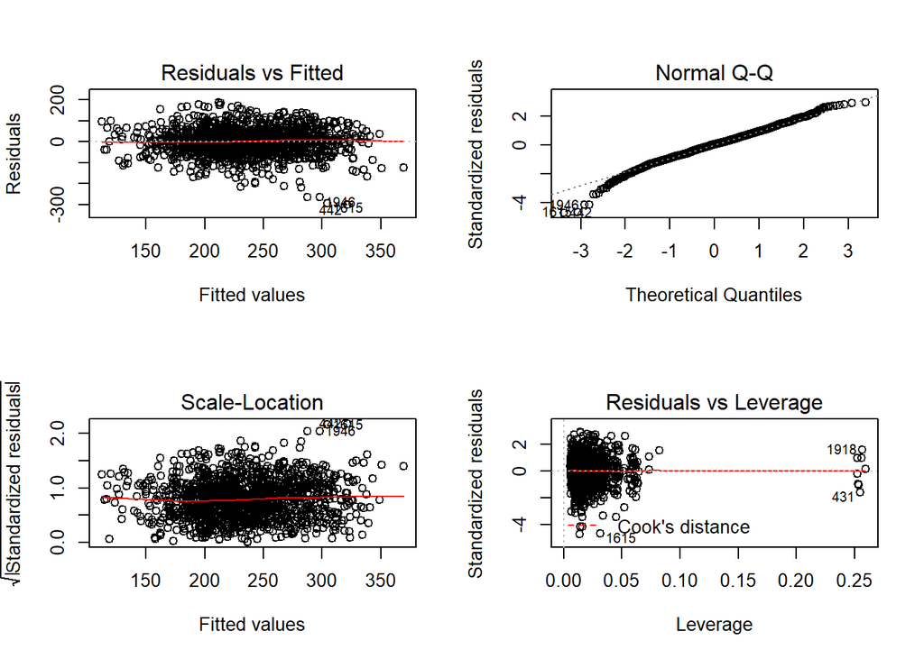

**From the 4 plots, we can see that the model is quite good except for a few data exceeds -3 in plot 4.**